# **Credit Risk Modeling**

# **IV. EDA Model**

## **1. Data Spliting**

```python
# EAD model datasets
ead_inputs_train, ead_inputs_test, ead_targets_train, ead_targets_test = train_test_split(loan_data_defaults, loan_data_defaults['CCF'], test_size = 0.2, random_state = 42)
# Takes a set of inputs and a set of targets as arguments. Splits the inputs and the targets into four dataframes:
# Inputs - Train, Inputs - Test, Targets - Train, Targets - Test.
```

```python
# Here we keep only the variables we need for the model.
X_ead_inputs_train = ead_inputs_train[list_feat_to_consider]
X_ead_inputs_test = ead_inputs_test[list_feat_to_consider]
y_ead_targets_train = ead_targets_train
y_ead_targets_test = ead_targets_test
```

```python
X_ead_inputs_train.shape
```

```
(214847, 148)
```

## **2. EDA linear regression model**

```python
reg_ead =  MyLinearRegression_with_p_values()
# We create an instance of an object from the 'LogisticRegression' class.
reg_ead.fit(X_ead_inputs_train, y_ead_targets_train)
# Estimates the coefficients of the object from the 'LogisticRegression' class
# with inputs (independent variables) contained in the first dataframe
# and targets (dependent variables) contained in the second dataframe.
```

```
<__main__.MyLinearRegression_with_p_values at 0x25eeda022a0>
```

```python
# List of the feature names used in the regression
feature_name = X_ead_inputs_train.columns.values
```

```python
summary_table = pd.DataFrame(columns = ['Feature name'], data = feature_name)
# Creates a dataframe with a column titled 'Feature name' and row values contained in the 'feature_name' variable.
summary_table['Coefficients'] = np.transpose(reg_ead.coef_)
# Creates a new column in the dataframe, called 'Coefficients',
# with row values the transposed coefficients from the 'LogisticRegression' object.
summary_table.index = summary_table.index + 1
# Increases the index of every row of the dataframe with 1.
summary_table.loc[0] = ['Intercept', reg_ead.intercept_]
# Assigns values of the row with index 0 of the dataframe.
summary_table = summary_table.sort_index()
# Sorts the dataframe by index.
p_values = reg_ead.p
# We take the result of the newly added method 'p_values' and store it in a variable 'p_values'.
p_values = np.append(np.nan, np.array(p_values))
# We add the value 'NaN' in the beginning of the variable with p-values.
summary_table['p_values'] = p_values
# In the 'summary_table' dataframe, we add a new column, called 'p_values', containing the values from the 'p_values' variable.
summary_table
```

|  | Feature name | Coefficients | p_values |
| --- | --- | --- | --- |
| 0 | Intercept | -6.277233e+10 | NaN |
| 1 | grade:A | -7.086988e-03 | 0.000000e+00 |
| 2 | grade:B | -3.845192e-03 | 2.220446e-16 |
| 3 | grade:D | 3.534587e-03 | 2.276349e-06 |
| 4 | grade:E | 5.250706e-04 | 6.022328e-01 |
| 5 | grade:F | -1.495733e-03 | 2.730482e-01 |
| 6 | grade:G | 5.929538e-03 | 7.841856e-04 |
| 7 | home_ownership:RENT_OTHER_NONE_ANY | 2.125067e-03 | 1.478660e-08 |
| 8 | addr_state:MT_SC | -3.549056e-03 | 1.213999e-02 |
| 9 | addr_state:CT_IL_RI_GA | -1.991568e-03 | 5.015397e-04 |
| 10 | addr_state:AZ_CA_AK_DE | 2.119721e-03 | 5.073028e-07 |
| 11 | addr_state:AR_AL | -1.002079e-03 | 3.268664e-01 |
| 12 | addr_state:NE_MS | -2.974585e-03 | 5.715011e-02 |
| 13 | verification_status:Not Verified | -4.279236e-05 | 9.183738e-01 |
| 14 | verification_status:Verified | -6.526732e-04 | 7.128991e-02 |
| 15 | purpose:debt_consolidation | -4.633305e-03 | 0.000000e+00 |
| 16 | purpose:credit_card | -4.891742e-03 | 0.000000e+00 |
| 17 | purpose:sm_b__mov__ren_en__house__medic | 1.389739e-03 | 9.436411e-02 |
| 18 | initial_list_status:f | -3.670692e-03 | 0.000000e+00 |
| 19 | application_type:Joint App | 1.900580e-02 | 0.000000e+00 |
| 20 | debt_settlement_flag:Y | -7.770907e-03 | 0.000000e+00 |
| 21 | term:60 | 2.209130e-02 | 0.000000e+00 |
| 22 | delinq_record_risk_score:1-2 | -3.734976e-03 | 7.250058e-08 |
| 23 | delinq_record_risk_score:3-7 | 2.768413e-03 | 9.386465e-02 |
| 24 | loan_amnt:2500-6500 | 3.456956e-04 | 7.621472e-01 |
| 25 | loan_amnt:6500-9500 | 8.616327e-03 | 1.970180e-11 |
| 26 | loan_amnt:9500-11000 | 1.028572e-02 | 2.220446e-15 |
| 27 | loan_amnt:11000-17500 | 8.681514e-03 | 5.292433e-12 |
| 28 | loan_amnt:17500-28500 | 8.695926e-03 | 3.258549e-11 |
| 29 | loan_amnt:>=28500 | 1.349145e-02 | 0.000000e+00 |

[output cut: 119 more lines]

#### **High-Level Observations**

**Extreme Coefficients:**

- **Variables like principal_paid_ratio:*.** and Intercept have massively large coefficients (~6.277e+10). This likely points to perfect multicollinearity or data leakage.
- **Similarly, out_prncp:>0** has an extreme negative coefficient. This is suspicious and likely also due to leakage, as it directly indicates payment progress.

**P-values:**

- **Many features** (e.g., grade:A, term:60, last_pymnt_amnt:*, fico_range_high:*) are statistically significant (p < 0.05).
- **Several features have high p-values** (e.g., verification_status:Not Verified, loan_amnt:2500-6500, inq_last_6mths:>=4), suggesting low explanatory power for those bins.

**Multicollinearity:**

- **Features with identical coefficients and p-values** (e.g., all principal_paid_ratio:* have the same value) likely come from one-hot encoding with a constant target pattern, a major red flag.

#### **Interpretation of Key Variables**

**Credit Risk-Related:**

**Payment Behavior:**

**Loan & Borrower Attributes:**

**Loan Purpose:**

**Flags for Potential Data Leakage or Modeling Errors:**

- **principal_paid_ratio:*:** All have the same massive coefficient and p-value = 0. Indicates data leakage or perfect separation.
- **out_prncp:>0** Target leakage — reveals payment status (and indirectly LGD). Should not be used in modeling.

#### **Remove Potentially Leaky Features:**

- **principal_paid_ratio**
- **out_prncp**
- **Possibly last_pymnt_amnt** (if it occurs after LGD is measured)

## **3. Model Validation**

```python
y_hat_test_ead = reg_ead.predict(X_ead_inputs_test)
# Calculates the predicted values for the dependent variable (targets)
# based on the values of the independent variables (inputs) supplied as an argument.
```

```python
# create a temporary copy y_ead_targets_test
y_ead_targets_test_temp = y_ead_targets_test
# We reset the index of a dataframe.
y_ead_targets_test_temp = y_ead_targets_test_temp.reset_index(drop = True)
# We calculate the correlation between actual and predicted values.
pd.concat([y_ead_targets_test_temp, pd.DataFrame(y_hat_test_ead)], axis = 1).corr()
```

|  | CCF | 0 |
| --- | --- | --- |
| CCF | 1.000000 | 0.945383 |
| 0 | 0.945383 | 1.000000 |

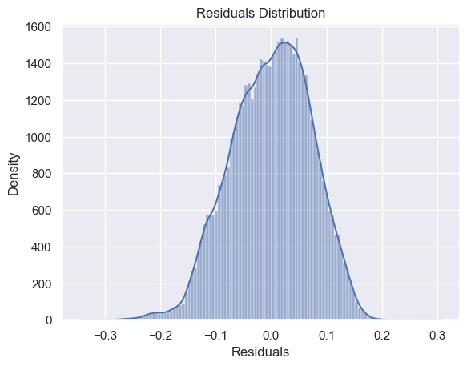

```python
import seaborn as sns
import matplotlib.pyplot as plt

# Plot histogram with KDE (kernel density estimation)
sns.histplot(ead_targets_test - y_hat_test_ead, kde=True)
plt.title('Residuals Distribution')
plt.xlabel('Residuals')
plt.ylabel('Density')
plt.show()
```

**The residual distribution presents a nice shape of normal distribution.**

```python
pd.DataFrame(y_hat_test_ead).describe()
# Shows some descriptive statisics for the values of a column.
```

|  | 0 |
| --- | --- |
| count | 53712.000000 |
| mean | 0.697367 |
| std | 0.206867 |
| min | 0.072136 |
| 25% | 0.604681 |
| 50% | 0.824738 |
| 75% | 0.852617 |
| max | 0.965729 |

```python
y_hat_test_ead = np.where(y_hat_test_ead < 0, 0, y_hat_test_ead)
y_hat_test_ead = np.where(y_hat_test_ead > 1, 1, y_hat_test_ead)
# We set predicted values that are greater than 1 to 1 and predicted values that are less than 0 to 0.
```

```python
### targets prediction
y_pred = y_hat_test_ead
y_true = y_ead_targets_test

# Evaluate the metrics
mse = mean_squared_error(y_true, y_pred)
rmse = np.sqrt(mse)
mae = mean_absolute_error(y_true, y_pred)
r2 = r2_score(y_true, y_pred)

print(f"MSE: {mse:.6f}")
print(f"RMSE: {rmse:.6f}")
print(f"MAE: {mae:.6f}")
print(f"R²: {r2:.6f}")
```

```
MSE: 0.005099
RMSE: 0.071405
MAE: 0.058248
R²: 0.893746
```

### **Interpretation**

**The model evaluation results and correlation matrix indicate strong predictive performance.**

#### **Model Evaluation Metrics:**

- **MSE (Mean Squared Error) = 0.005099**: Indicates a low average squared error between predicted and actual values — lower is better.
- **RMSE (Root Mean Squared Error) = 0.071405**: A more interpretable version of MSE (in original units). A small RMSE shows good predictive accuracy.
- **MAE (Mean Absolute Error) = 0.058248**: Low average magnitude of errors, showing that predictions are consistently close to actuals.
- **R² (R-squared) = 0.893746**: Suggests that ~89.4% of the variance in the target variable is explained by the model — strong fit.

**Conclusion:** The model is performing well with low error metrics and high explanatory power.

# **V. Expected Loss Calculation**

## **1. Database to use**

```python
# The overall preprocessed dataset
loan_data_07_18.head()
```

| Index | id | grade:A | grade:B | grade:C | grade:D | grade:E | grade:F | grade:G | home_ownership:MORTGAGE | home_ownership:OWN | home_ownership:RENT_OTHER_NONE_ANY | addr_state:DC_VT_OR | addr_state:WV_ME_NH_IA_WA_CO | addr_state:MT_SC | addr_state:UT_WY_KS | addr_state:CT_IL_RI_GA | addr_state:WI_ID_MA | addr_state:AZ_CA_AK_DE | addr_state:VA_MN_TX_OH_MI_HI | addr_state:PA_NC_KY_NJ | addr_state:NM_SD_TN_MD_MO_IN_NV_FL | addr_state:NY_ND_LA_OK | addr_state:AR_AL | addr_state:NE_MS | verification_status:Not Verified | verification_status:Source Verified | verification_status:Verified | purpose:debt_consolidation | purpose:credit_card | … |
| --- | --- | --- | --- | --- | --- | --- | --- | --- | --- | --- | --- | --- | --- | --- | --- | --- | --- | --- | --- | --- | --- | --- | --- | --- | --- | --- | --- | --- | --- | --- |
| 0 | 68407277 | 0 | 0 | 1 | 0 | 0 | 0 | 0 | 1 | 0 | 0 | 0 | 0 | 0 | 0 | 0 | 0 | 0 | 0 | 1 | 0 | 0 | 0 | 0 | 1 | 0 | 0 | 1 | 0 | … |
| 1 | 68355089 | 0 | 0 | 1 | 0 | 0 | 0 | 0 | 1 | 0 | 0 | 0 | 0 | 0 | 0 | 0 | 0 | 0 | 0 | 0 | 1 | 0 | 0 | 0 | 1 | 0 | 0 | 0 | 0 | … |
| 2 | 68341763 | 0 | 1 | 0 | 0 | 0 | 0 | 0 | 1 | 0 | 0 | 0 | 0 | 0 | 0 | 1 | 0 | 0 | 0 | 0 | 0 | 0 | 0 | 0 | 1 | 0 | 0 | 0 | 0 | … |
| 4 | 68476807 | 0 | 0 | 0 | 0 | 0 | 1 | 0 | 1 | 0 | 0 | 0 | 0 | 0 | 0 | 0 | 0 | 0 | 0 | 1 | 0 | 0 | 0 | 0 | 0 | 1 | 0 | 0 | 0 | … |
| 5 | 68426831 | 0 | 0 | 1 | 0 | 0 | 0 | 0 | 0 | 0 | 1 | 0 | 0 | 0 | 0 | 1 | 0 | 0 | 0 | 0 | 0 | 0 | 0 | 0 | 0 | 1 | 0 | 1 | 0 | … |

```python
# Shape of the dataset
loan_data_07_18.shape
```

```
(1371166, 436)
```

## **2. ExpectedLossPipeline Class**

**We’ll define a robust ExpectedLossPipeline class that:**

- **Accepts models for PD, LGD (2-stage), and CCF**
- **Computes EAD and EL**
- **Handles default logic properly**

```python
class ExpectedLossPipeline:
    def __init__(self, pd_model, lgd_stage1_model, lgd_stage2_model, ccf_model):
        self.pd_model = pd_model
        self.lgd_stage1_model = lgd_stage1_model
        self.lgd_stage2_model = lgd_stage2_model
        self.ccf_model = ccf_model

    def predict_pd(self, X):
        return self.pd_model.predict_proba(X)[:, 1]

    def predict_lgd(self, X, is_default):
        lgd_pred = pd.Series(0.0, index=X.index)
        default_idx = is_default[is_default].index

        if not default_idx.empty:
            stage1_preds = self.lgd_stage1_model.predict(X.loc[default_idx])
            valid_idx = default_idx[stage1_preds == 1]
            if not valid_idx.empty:
                lgd_pred.loc[valid_idx] = self.lgd_stage2_model.predict(X.loc[valid_idx])

        return lgd_pred

    def predict_ccf(self, X, is_default):
        ccf_pred = pd.Series(0.0, index=X.index)
        default_idx = is_default[is_default].index

        if not default_idx.empty:
            ccf_pred.loc[default_idx] = self.ccf_model.predict(X.loc[default_idx])

        return pd.Series(np.clip(ccf_pred, 0, 1), index=X.index)

    def predict_ead(self, ccf, funded_amnt):
        return ccf * funded_amnt

    def predict_el(self, X, funded_amnt, is_default):
        pd_pred = self.predict_pd(X)
        lgd_pred = self.predict_lgd(X, is_default)
        ccf_pred = self.predict_ccf(X, is_default)
        ead_pred = self.predict_ead(ccf_pred, funded_amnt)

        el = pd_pred * lgd_pred * ead_pred
        return pd.DataFrame({
            'PD': pd_pred,
            'LGD': lgd_pred,
            'CCF': ccf_pred,
            'EAD': ead_pred,
            'EL': el
        }, index=X.index)
```

#### **Application to loan_data_07_18 dataset**

```python
# Start from a clean base DataFrame that includes all required columns
base_df = loan_data_07_18[['loan_status', 'funded_amnt'] + list_feat_to_consider].copy()

# Filter out rows with any missing values (to avoid alignment issues)
base_df.dropna(inplace=True)

# Define inputs based on the same index
X_loan_data = base_df[list_feat_to_consider]
funded_amnt = base_df['funded_amnt']
is_default = base_df['loan_status'].isin(['Charged Off', 'Default', 'Does not meet the credit policy. Status:Charged Off'])

# Instantiate the pipeline
el_pipeline = ExpectedLossPipeline(
    pd_model = reg1,
    lgd_stage1_model =  LGBM_lgd_st_1,
    lgd_stage2_model = tuned_lgb_model,
    ccf_model = reg_ead
)

# Predict EL and components
el_outputs = el_pipeline.predict_el(X_loan_data, funded_amnt, is_default)
print(el_outputs.head())
```

```
             PD  LGD  CCF  EAD   EL
Index
0      0.206528  0.0  0.0  0.0  0.0
1      0.011805  0.0  0.0  0.0  0.0
2      0.000097  0.0  0.0  0.0  0.0
4      0.000064  0.0  0.0  0.0  0.0
5      0.000132  0.0  0.0  0.0  0.0
```

#### **Sample of the outputs**

```python
el_outputs.sample(10)
```

| Index | PD | LGD | CCF | EAD | EL |
| --- | --- | --- | --- | --- | --- |
| 2114078 | 0.000080 | 0.000000 | 0.000000 | 0.000000 | 0.000000 |
| 1186029 | 0.000035 | 0.000000 | 0.000000 | 0.000000 | 0.000000 |
| 1703623 | 0.999755 | 0.000000 | 0.482697 | 7240.447998 | 0.000000 |
| 1156867 | 0.191538 | 0.000000 | 0.245689 | 3685.340881 | 0.000000 |
| 922110 | 0.000078 | 0.000000 | 0.000000 | 0.000000 | 0.000000 |
| 209945 | 0.259163 | 0.000000 | 0.000000 | 0.000000 | 0.000000 |
| 1285100 | 0.999994 | 0.117669 | 0.818375 | 9452.227020 | 1112.229999 |
| 177546 | 0.004882 | 0.000000 | 0.000000 | 0.000000 | 0.000000 |
| 325222 | 0.017994 | 0.000000 | 0.000000 | 0.000000 | 0.000000 |
| 229209 | 0.011792 | 0.000000 | 0.000000 | 0.000000 | 0.000000 |

**Confirmation: The EL formula is working**

**EL = PD × LGD × EAD**

**So we’re now:**

- **Predicting PD on all loans**
- **Applying LGD/CCF only to defaulted ones**
- **Using funded amount × CCF for EAD**
- **Correctly computing Expected Loss**

## **3. Cross-Validation Support**

### **Class ELCrossValidator**

**It performs cross-validation for a complete Expected Loss pipeline, including:**

- **PD model (classification with ROC AUC)**
- **LGD two-stage model (classification + regression, scored using RMSE on LGD)**
- **CCF model (regression, scored using RMSE)**

**We can pass any models compatible with fit/predict (like LightGBM, XGBoost, LogisticRegression, etc.), and it will handle training, validation, and scoring in cross-validation folds.**

```python
from sklearn.metrics import roc_auc_score, mean_squared_error
from sklearn.model_selection import KFold
import numpy as np
import pandas as pd

class ELCrossValidator:
    def __init__(self, pd_model, lgd_stage1_model, lgd_stage2_model, ccf_model, n_splits=5, random_state=42):
        self.pd_model = pd_model
        self.lgd_stage1_model = lgd_stage1_model
        self.lgd_stage2_model = lgd_stage2_model
        self.ccf_model = ccf_model
        self.n_splits = n_splits
        self.random_state = random_state

    def cross_validate(self, X, y_pd, y_lgd, y_ccf, is_default):
        kf = KFold(n_splits=self.n_splits, shuffle=True, random_state=self.random_state)

        auc_scores = []
        lgd_rmse_scores = []
        ccf_rmse_scores = []

        for fold, (train_idx, val_idx) in enumerate(kf.split(X)):
            print(f"Fold {fold + 1}/{self.n_splits}")

            # Split data
            X_train, X_val = X.iloc[train_idx], X.iloc[val_idx]
            y_pd_train, y_pd_val = y_pd.iloc[train_idx], y_pd.iloc[val_idx]
            y_lgd_train, y_lgd_val = y_lgd.iloc[train_idx], y_lgd.iloc[val_idx]
            y_ccf_train, y_ccf_val = y_ccf.iloc[train_idx], y_ccf.iloc[val_idx]
            is_default_train, is_default_val = is_default.iloc[train_idx], is_default.iloc[val_idx]

            # --- PD Model ---
            self.pd_model.fit(X_train, y_pd_train)
            pd_probs = self.pd_model.predict_proba(X_val)[:, 1]
            auc = roc_auc_score(y_pd_val, pd_probs)
            auc_scores.append(auc)

            # --- LGD Model (Two-Stage) ---
            lgd_rmse = np.nan
            default_train_idx = is_default_train[is_default_train].index
            default_val_idx = is_default_val[is_default_val].index

            if not default_train_idx.empty and not default_val_idx.empty:
                # Stage 1
                self.lgd_stage1_model.fit(X_train.loc[default_train_idx], y_lgd_train.loc[default_train_idx] > 0)

                # Stage 2 (only for predicted positive LGD from stage 1)
                stage1_preds = self.lgd_stage1_model.predict(X_train.loc[default_train_idx])
                stage2_idx = default_train_idx[stage1_preds == 1]
                if not stage2_idx.empty:
                    self.lgd_stage2_model.fit(X_train.loc[stage2_idx], y_lgd_train.loc[stage2_idx])

                # Validation
                stage1_val_preds = self.lgd_stage1_model.predict(X_val.loc[default_val_idx])
                stage2_val_idx = default_val_idx[stage1_val_preds == 1]

                if not stage2_val_idx.empty:
                    lgd_preds = self.lgd_stage2_model.predict(X_val.loc[stage2_val_idx])
                    lgd_rmse = mean_squared_error(y_lgd_val.loc[stage2_val_idx], lgd_preds, squared=False)
                    lgd_rmse_scores.append(lgd_rmse)

            # --- CCF Model ---
            if not default_train_idx.empty and not default_val_idx.empty:
                self.ccf_model.fit(X_train.loc[default_train_idx], y_ccf_train.loc[default_train_idx])
                ccf_preds = self.ccf_model.predict(X_val.loc[default_val_idx])
                ccf_rmse = mean_squared_error(y_ccf_val.loc[default_val_idx], ccf_preds, squared=False)
                ccf_rmse_scores.append(ccf_rmse)

        return {
            'PD_AUC_scores': auc_scores,
            'LGD_RMSE_scores': lgd_rmse_scores,
            'CCF_RMSE_scores': ccf_rmse_scores
        }
```

```python
cv = ELCrossValidator(
    pd_model=reg1,
    lgd_stage1_model=LGBM_lgd_st_1,
    lgd_stage2_model=tuned_lgb_model,
    ccf_model=reg_ead,
    n_splits=5
)

X_data = loan_data_07_18[list_feat_to_consider]
y_pd = loan_data_07_18['good_bad']
lgd = loan_data_07_18['recovery_rate']
ccf = loan_data_07_18['CCF']
is_default = loan_data_07_18['is_default']

def clean_column_names(df):
    df.columns = df.columns.str.replace(r"[^\w]", "_", regex=True)
    return df

X_data = clean_column_names(X_data)

scores = cv.cross_validate(
    X = X_data,
    y_pd = y_pd,               # Binary target: 1 if default
    y_lgd = lgd,               # LGD values (continuous, only for defaults)
    y_ccf = ccf,               # CCF values (continuous, only for defaults)
    is_default=is_default    # Boolean Series
)

print(scores)
```

[output not shown]

[output not shown]

[output not shown]

[output not shown]

[output not shown]

[output not shown]

## **4. Visualize EL Distribution and Risk Tiers**

**Use matplotlib or seaborn to visualize EL or assign risk tiers.**

```python
import seaborn as sns
import matplotlib.pyplot as plt

def plot_el_distribution(el_df, threshold=None):
    # Exclude EL = 0 values
    el_df = el_df[el_df['EL'] > 0]

    # Apply optional threshold filter
    if threshold is not None:
        el_df = el_df[el_df['EL'] < threshold]

    # Plot
    plt.figure(figsize=(10, 6))
    sns.histplot(el_df['EL'], bins=100, kde=True, color='blue')
    plt.title(f'Expected Loss Distribution{" (EL < " + str(threshold) + ")" if threshold else ""}')
    plt.xlabel('Expected Loss')
    plt.ylabel('Frequency')
    plt.show()

def assign_risk_tiers(el_df):
    bins = [0, 100, 500, 1000, 5000, np.inf]
    labels = ['Very Low', 'Low', 'Moderate', 'High', 'Very High']
    el_df['Risk_Tier'] = pd.cut(el_df['EL'], bins=bins, labels=labels)
    return el_df
```

#### **1. Make sure your DataFrame is ready**

**It must have an "EL" column with Expected Loss values:**

```python
# Example structure of el_df
print(el_outputs[['PD', 'LGD', 'EAD', 'EL']].head())
```

```
             PD  LGD  EAD   EL
Index
0      0.206528  0.0  0.0  0.0
1      0.011805  0.0  0.0  0.0
2      0.000097  0.0  0.0  0.0
4      0.000064  0.0  0.0  0.0
5      0.000132  0.0  0.0  0.0
```

#### **2. Assign Risk Tiers**

**Call the assign_risk_tiers() function to categorize loans into tiers:**

```python
el_df = assign_risk_tiers(el_outputs)
print(el_df[['EL', 'Risk_Tier']].head())
```

```
        EL Risk_Tier
Index
0      0.0       NaN
1      0.0       NaN
2      0.0       NaN
4      0.0       NaN
5      0.0       NaN
```

**This adds a new column Risk_Tier with values like "Very Low", "Moderate", etc., based on EL thresholds.**

#### **3. Plot Expected Loss Distribution**

**Now plot the EL distribution:**

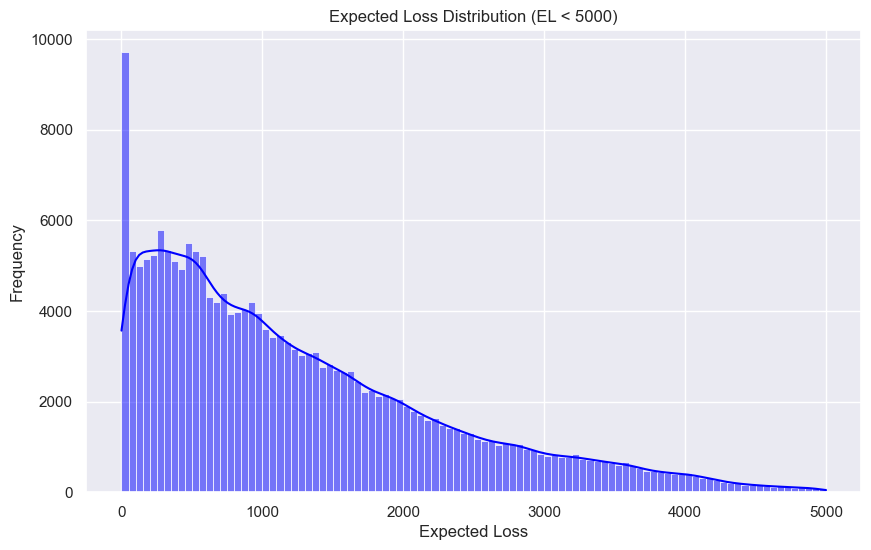

```python
plot_el_distribution(el_df, 5000)
```

#### **4. Plot by Risk Tier**

**Visualize EL by Risk Tier:**

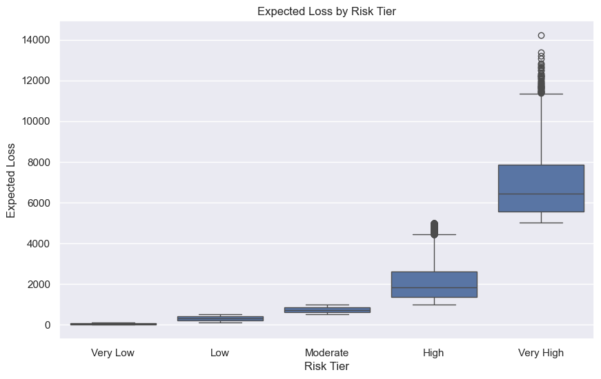

```python
plt.figure(figsize=(10, 6))
sns.boxplot(data=el_df, x='Risk_Tier', y='EL', order=['Very Low', 'Low', 'Moderate', 'High', 'Very High'])
plt.title('Expected Loss by Risk Tier')
plt.xlabel('Risk Tier')
plt.ylabel('Expected Loss')
plt.show()
```

```python
def tabulate_el_bins(el_df, upper_limit=6000, bins=50):
    # Filter EL > 0 and EL < upper_limit
    # (el_df['EL'] > 0) &
    filtered_df = el_df[(el_df['EL'] < upper_limit)].copy()

    # Define bin edges starting at 0
    bin_edges = np.linspace(0, upper_limit, bins + 1)

    # Bin EL values
    filtered_df['EL_Bin'] = pd.cut(filtered_df['EL'], bins=bin_edges, include_lowest=True)

    # Count frequency in each bin
    bin_counts = filtered_df['EL_Bin'].value_counts().sort_index()

    return bin_counts
```

```python
el_bin_table = tabulate_el_bins(el_df, upper_limit=6000, bins=120)
print(el_bin_table)
```

```
EL_Bin
(-0.001, 50.0]      1180150
(50.0, 100.0]          5313
(100.0, 150.0]         4985
(150.0, 200.0]         5141
(200.0, 250.0]         5245
(250.0, 300.0]         5782
(300.0, 350.0]         5332
(350.0, 400.0]         5095
(400.0, 450.0]         4930
(450.0, 500.0]         5495
(500.0, 550.0]         5312
(550.0, 600.0]         5211
(600.0, 650.0]         4305
(650.0, 700.0]         4186
(700.0, 750.0]         4397
(750.0, 800.0]         3940
(800.0, 850.0]         3980
(850.0, 900.0]         4037
(900.0, 950.0]         4200
(950.0, 1000.0]        3947
(1000.0, 1050.0]       3612
(1050.0, 1100.0]       3424
(1100.0, 1150.0]       3471
(1150.0, 1200.0]       3306
(1200.0, 1250.0]       3150
(1250.0, 1300.0]       3020
(1300.0, 1350.0]       3064
(1350.0, 1400.0]       3095
(1400.0, 1450.0]       2769
(1450.0, 1500.0]       2822
(1500.0, 1550.0]       2692
(1550.0, 1600.0]       2662
(1600.0, 1650.0]       2666
(1650.0, 1700.0]       2440
(1700.0, 1750.0]       2203
(1750.0, 1800.0]       2264
(1800.0, 1850.0]       2130
(1850.0, 1900.0]       2169
(1900.0, 1950.0]       2086
```

[output cut: 67 more lines]

```
(5300.0, 5350.0]         54
(5350.0, 5400.0]         63
(5400.0, 5450.0]         68
(5450.0, 5500.0]         55
(5500.0, 5550.0]         61
(5550.0, 5600.0]         50
(5600.0, 5650.0]         40
(5650.0, 5700.0]         45
(5700.0, 5750.0]         34
(5750.0, 5800.0]         49
(5800.0, 5850.0]         51
(5850.0, 5900.0]         43
(5900.0, 5950.0]         53
(5950.0, 6000.0]         37
Name: count, dtype: int64
```

```python
# Number of loans with expected loss = 0
el_zero_count = (el_df['EL'] == 0).sum()
print(f"Number of customers with EL = 0: {el_zero_count}")
```

```
Number of customers with EL = 0: 1170443
```

#### **High-Level Interpretation**

- **Most loans (≈ 1.18 million) have very low expected loss — between 0 and 50 (≈ 1.17 million have expected loss equal to 0).**
- **For expected loss between 0 and 50, we have 9 707 loans.**
- **After 50, the number of loans in each bin decreases gradually.**
- **This confirms a heavy right-skew in the EL distribution — most customers have low expected loss, while a smaller number have very high risk.**

#### **Business Interpretation**

- **The majority of your loan book is very low risk, which is a healthy indicator.**
- **A long tail of higher EL values points to a smaller, riskier borrower group — useful for:**
  - **Tightening credit policies.**
  - **Allocating reserves.**
  - **Prioritizing recovery efforts.**

### **Analyze risk tiers**

```python
el_df['Risk_Tier'].value_counts()
```

```
Risk_Tier
High         97327
Moderate     43515
Low          42005
Very Low     15020
Very High     2849
Name: count, dtype: int64
```

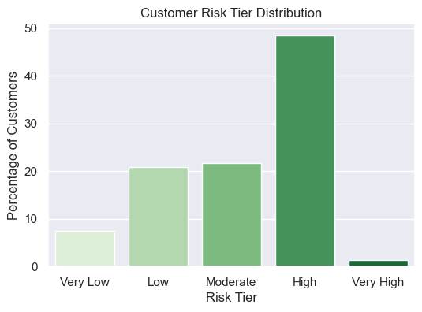

```python
# Count and percentage table
risk_counts = el_df['Risk_Tier'].value_counts()
risk_percent = (risk_counts / risk_counts.sum()) * 100
risk_df = pd.DataFrame({
    'Risk_Tier': risk_counts.index,
    'Percent': risk_percent.values
})
risk_df['Cumulative_Percent'] = risk_df['Percent'].cumsum()

# Bar plot using hue to satisfy the warning
plt.figure(figsize=(6, 4))
sns.barplot(
    data=risk_df,
    x='Risk_Tier',
    y='Percent',
    hue='Risk_Tier',  # explicitly set hue
    palette='Greens',
    dodge=False,
    legend=False      # suppress legend since hue is artificial here
)
plt.ylabel('Percentage of Customers')
plt.xlabel('Risk Tier')
plt.title('Customer Risk Tier Distribution')
plt.show()
```

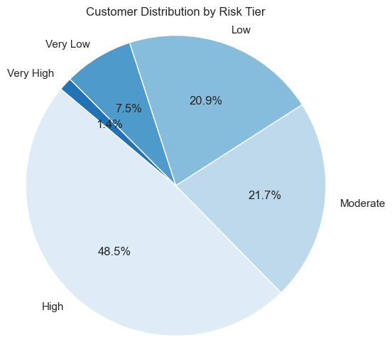

```python
# Calculate counts and percentages
risk_counts = el_df['Risk_Tier'].value_counts()
risk_percent = (risk_counts / risk_counts.sum()) * 100

# Plot pie chart
plt.figure(figsize=(6, 6))
plt.pie(risk_percent, labels=risk_percent.index, autopct='%1.1f%%', startangle=140, colors=plt.cm.Blues(range(30, 256, 40)))
plt.title('Customer Distribution by Risk Tier')
plt.axis('equal')  # Equal aspect ratio ensures pie is a circle
plt.show()
```

#### **Interpret Strategy**

- **Very High / High Risk:** Investigate further for potential fraud, tighter lending conditions.
- **Moderate:** Closely monitor performance. May need pricing strategy changes.
- **Low / Very Low:** Consider retention strategies, upselling safer products.

# **VI. Conclusion of Credit Risk Modeling – Part 2**

**In this second phase of the credit risk modeling project, we developed a comprehensive and production-ready framework for expected loss estimation, integrating Probability of Default (PD), Loss Given Default (LGD), and Exposure at Default (EAD) models.**

### **1. Data Preparation and Exploration**

- **The process began with loading and exploring the Lending Club dataset.**
- **Extensive EDA helped identify relevant variables, and categorical reference levels were carefully selected for consistency in modeling.**
- **A rigorous feature selection pipeline was applied using p-values from logistic regression, resulting in a refined set of 148 predictive features and the elimination of 102 non-contributing variables.**

### **2. PD Model Estimation**

- **The Probability of Default was modeled using both Logistic Regression and Random Forest classifiers.**
- **After evaluating model interpretability, performance, and feature importances, Logistic Regression was retained for its transparency and solid predictive ability.**
- **Model quality was validated using:**
  - **Gini coefficient.**
  - **Kolmogorov-Smirnov statistic.**
- **The PD model was then used to:**
  - **Score individual accounts.**
  - **Convert credit scores to PD values.**
  - **Set cut-off thresholds for risk classification.**
  - **Analyze Population Stability Index (PSI) between the 2019 (train) and 2020 (validation) datasets for monitoring model stability over time.**

### **3. LGD Model – Two-Stage Modeling Approach**

**The Loss Given Default (LGD) modeling was performed in two stages:**

- **Stage 1 – Classification (predicting full loss vs partial loss):**
  - **Models evaluated:** Logistic Regression, Random Forest, XGBoost, and LightGBM.
  - **Final choice:** LightGBM Classifier, offering optimal balance between performance and efficiency.
- **Stage 2 – Regression (predicting LGD value for non-zero cases):**
  - **Models evaluated:** Linear Regression, Random Forest, Gradient Boosting, XGBoost (with tuning), and LightGBM.
  - **Final choice:** Tuned LightGBM Regressor, delivering the best trade-off across:
    - **RMSE = 0.0767**
    - **MAE = 0.0463**
    - **R² = 0.3438**

### **4. EAD Model**

- **Exposure at Default (EAD) was estimated using Linear Regression.**
- **The model showed strong predictive power with:**
  - **MSE = 0.0051**
  - **RMSE = 0.0714**
  - **MAE = 0.0582**
  - **R² = 0.8937**

### **5. Expected Loss (EL) Estimation and Interpretation**

- **A custom ExpectedLossPipeline class was developed to combine PD, LGD, and EAD estimates into a unified EL metric.**
- **Key additions included:**
  - **Cross-validation support.**
  - **Visualization of Expected Loss distribution.**
  - **Risk tier assignment and interpretation.**
  - **This enabled clear segmentation of accounts into risk tiers, aiding in strategic credit decision-making.**

### **6. Final Takeaways**

- **The developed models are robust, interpretable, and highly applicable to real-world credit portfolios.**
- **The approach enables dynamic monitoring of risk (via PSI), accurate loss forecasting (via EL), and actionable customer segmentation (via risk tiers).**
- **This pipeline can serve as a solid foundation for credit scoring, provisioning, and capital adequacy planning under frameworks like IFRS 9 or Basel II/III.**